# Portfolio Website Project Proposal

IBM 6500 | Module 10

Author

Simran Kaur

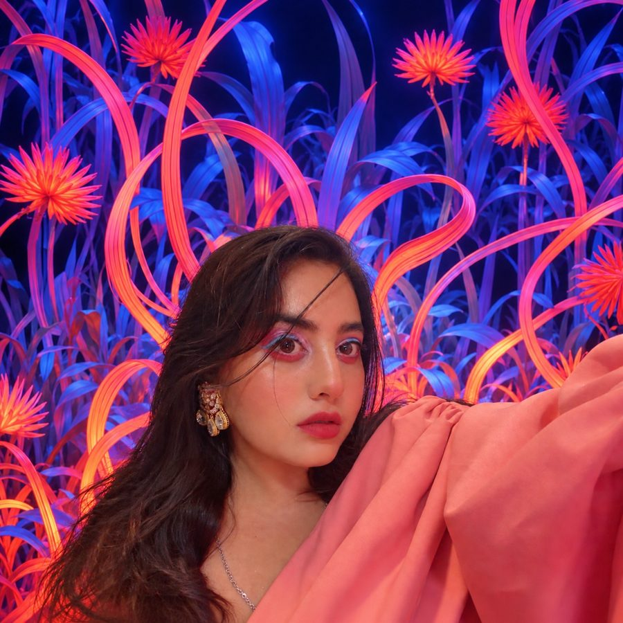

Simran Kaur / Portfolio concept

## Creative thinking. Analytical curiosity.

Proposed structure, project workflows and page layouts for a Quarto portfolio aimed at marketing analyst roles in fashion and beauty.

## Overview

My goal is a professional portfolio that brings my digital marketing, creative strategy and marketing analytics work into one place. I want it to show more than final results. Each project page should show how I frame a business problem, work with the data and turn it into a recommendation.

The site will be built in Quarto, kept in a GitHub repo and deployed on Netlify, which rebuilds the site on every push. The site also becomes a data source: GA4 tracks it, and that traffic becomes one of the analytics projects.

## Website structure

Four tabs in the navigation: Home, Digital Marketing Projects, Marketing Analytics Projects and Resume. The GA4 traffic report and the Reveal.js presentation are projects inside Marketing Analytics, not separate tabs.

[figure not shown]

### What each tab holds

✦ Simran Kaur

HomeDigital MarketingMarketing AnalyticsResume

#### Home

Intro and personal statement · featured projects · education · certifications · experience · contact links

#### Digital Marketing Projects

2 project cards

*GA4 Channel Performance**Creative Brand Campaign*

#### Marketing Analytics Projects

Blog-style listing, 5 project posts with category filters

*Website Traffic – GA4**BigQuery SQL**Case 31**CEP**Reveal.js*

#### Resume

CV built with Markdown and the vitae package · PDF download

### Repo layout

`_quarto.yml` site config and navbar  
`index.qmd` Home  
`digital-marketing.qmd` tab listing  
`marketing-analytics.qmd` tab listing  
`resume.qmd` + `resume/cv.Rmd` (vitae)

`projects/dm/` one folder per digital marketing project  
`projects/ma/` one folder per analytics project  
`images/` shared assets  
`_site/` build output, deployed by Netlify

## Build and tracking workflow

Two workflows run the site. The first publishes it. The second turns its traffic into data for the GA4 report.

Publishing workflow

**Write**Pages and reports as .qmd in Positron

**Render**`quarto render` locally to check pages

**Commit**Push to the GitHub repo

**Deploy**Netlify builds from the repo on every push

**Live site**Public portfolio link for applications

Tracking and analytics workflow

**GA4 tag**Added to every page through `_quarto.yml`

**Search Console**Verify site, submit sitemap, get indexed

**Link GSC → GA4**Search queries appear next to traffic

**BigQuery export**Daily GA4 event export

**Looker Studio**Traffic and conversion dashboard

**Quarto report**Insights published as a project page

## Home page

The Home page introduces me and sends visitors to the work. It carries over the content I’ve already drafted: my education (bachelor’s in Graphic Design from Iowa State, graduate study in International Apparel Management and the MS in Digital Marketing & Analytics at Cal Poly Pomona), certifications in GA4, HubSpot, SQL and BigQuery, and my experience as a freelance designer and with the Trauma Resource Institute.

✦ Simran Kaur

HomeDigital MarketingMarketing AnalyticsResume

Photo

Hello, I'm Simran

#### Creative thinking. Analytical curiosity.

Two lines on who I am, what I do and the role I want.

Explore my workResume

#### Digital Marketing

Campaigns, channel performance and creative strategy2 projects →

#### Marketing Analytics

Data, research and insights5 projects →

Featured projects

dashboard preview

Portfolio Website Traffic – GA4

chart preview

CEP – AI-Assisted Meta-Analysis

campaign visual

Creative Brand Campaign

**Education**  
3 degree cards

**Certifications**  
GA4 · HubSpot · SQL · BigQuery

**Experience**  
Timeline

**Skills**  
R · SQL · GA4 · Tableau · Adobe

LinkedIn · GitHub · Email · Back to top

## Digital Marketing Projects

This tab shows strategy, channel and creative work. It uses a two-card grid, and each card opens a full project page.

✦ Simran Kaur

HomeDigital MarketingMarketing AnalyticsResume

Selected work

#### Digital Marketing Projects

Channel strategy, content and brand positioning.

GA4 report screenshot

#### GA4 Channel Performance

Which channels bring engaged visitors and revenue

*GA4**Acquisition**Strategy*

Read project →

campaign moodboard

#### Creative Brand Campaign

Positioning and campaign direction for a brand concept

*Branding**Content**Creative*

Read project →

Digital Marketing · Project 1

#### GA4 Channel Performance and Marketing Strategy

*GA4**Descriptive analytics**Channel strategy*

##### Data and source

GA4 e-commerce reporting data from the course micro-assignments (Google Merchandise Store demo account).

##### Target audience

Digital marketing managers and e-commerce teams.

##### Managerial problem

The channels that bring the most sessions aren't always the ones that bring engaged visitors or revenue. Budget should follow value, not traffic.

##### Research questions

- Which channels drive the most engaged sessions, conversions and revenue?
- How have revenue and engagement by channel changed over time?
- Where do new and returning users differ?

##### Methods

Descriptive statistics, percentage change, channel comparisons and a chi-square test on conversion rate by channel.

##### Expected impact

A clear case for prioritizing channels. Revenue attribution only where the data supports it.

Project workflow

**Access**GA4 demo property

**Pull reports**Acquisition, engagement, monetization

**Compare**Rates and % change by channel

**Visualize**Bar and trend charts

**Recommend**Channel priorities

Digital Marketing · Project 2

#### Creative Brand Campaign Concept

*Brand strategy**Content audit**Creative direction*

##### Data and source

My original creative assets and brand concept, plus public competitor campaign examples I collect.

##### Target audience

Brand managers and creative marketing teams.

##### Managerial problem

Building a distinctive, consistent brand identity in a crowded market.

##### Research questions

- Where is there open positioning space compared with competitors?
- Which visual direction and message fit the target customer?
- How should the campaign be tested once it runs?

##### Methods

Structured competitor content review, frequency counts of creative themes, a positioning map and descriptive comparisons. Performance testing would need extra data, so I'll design an A/B test plan.

##### Expected impact

A clear creative direction and a plan for testing it.

Project workflow

**Brief**Audience, goal, positioning

**Audit**Code competitor content themes

**Position**Map gaps and pick a direction

**Create**Moodboard, visuals, copy

**Test plan**A/B hooks and KPIs

## Marketing Analytics Projects

This tab is blog-style. It’s a Quarto listing of five project posts with category filters, so new analyses can be added over time.

✦ Simran Kaur

HomeDigital MarketingMarketing AnalyticsResume

Selected work

#### Marketing Analytics Projects

Case studies, data visualization, performance metrics and modeling.

*All**Web analytics**SQL**Survey research**Research synthesis**Presentation*

Looker dashboard

#### Portfolio Website Traffic – GA4

*GA4**BigQuery**Looker*

funnel chart

#### BigQuery SQL Analysis

*SQL**E-commerce*

regression table

#### Case 31 Analysis

*R**Survey**CFA*

dashboard view

#### CEP – AI-Assisted Meta-Analysis

*CALIPER**Usability*

title slide

#### Reveal.js Presentation

*Quarto**Storytelling*

Marketing Analytics · Project 1 · Required

#### Portfolio Website Traffic Analysis (GA4)

*GA4**Search Console**BigQuery**Looker Studio*

##### Data and source

GA4 events from this website, Search Console queries and rankings, and the daily BigQuery export.

##### Target audience

Me as the site owner, and hiring managers reviewing my work.

##### Managerial problem

A portfolio only helps if the right people find it and reach the resume or contact links. Right now I don't know how visitors arrive or where they drop off.

##### Research questions

- Which channels and search queries bring visitors?
- Which project pages get the most views and engagement?
- What share of visitors reach a key event: resume download, LinkedIn or GitHub click?
- How does engagement change over time?

##### Methods

SQL on the `events_*` tables to build sessions and key-event rates, engagement rates, traffic-source comparisons, Search Console CTR by position, and time-series charts in Looker Studio.

##### Expected impact

Better navigation, page order and calls to action, based on what visitors actually do.

##### Limitation

Traffic will be small, so the report stays descriptive and I'll avoid strong conclusions from thin numbers.

Project workflow

**Collect**GA4 events and key events

**Export**GA4 → BigQuery daily

**Query**UNNEST params, sessions, key events

**Dashboard**Looker Studio traffic and conversions

**Report**Quarto insights page

Marketing Analytics · Project 2

#### GA4 E-commerce Analysis Using BigQuery SQL

*BigQuery**SQL**Funnel*

##### Data and source

Google's public dataset `bigquery-public-data.ga4_obfuscated_sample_ecommerce.events_*`.

##### Target audience

E-commerce managers and marketing analysts.

##### Managerial problem

The GA4 interface only shows summaries. Finding patterns in purchase behavior takes raw event data.

##### Research questions

- How often do key events happen, and how active are users?
- Which acquisition sources bring buyers?
- Where do users drop out between product view, add to cart, checkout and purchase?

##### Methods

SQL filtering, grouping and aggregation, UNNEST, joins, window functions and CTEs, then descriptive analysis and charts.

##### Expected impact

Shows how raw event data becomes e-commerce insights a team can act on.

Project workflow

**Explore**Schema and event types

**Flatten**UNNEST event params

**Model**CTEs and window functions

**Summarize**Funnel and source tables

**Insights**Charts and findings

Marketing Analytics · Project 3

#### Case 31: Credit Union Member Analysis

*R**Survey research**Factor analysis*

##### Data and source

Case 31 member opinion survey for Employees Federal Credit Union, provided in IBM 6500.

##### Target audience

Credit union management and marketing teams.

##### Managerial problem

Understanding member awareness, how members see staff and service, and how those views differ between member groups.

##### Research questions

- How do awareness and perceptions differ across member groups? (R1–R6)
- How do perceived employee proficiency and operational effectiveness relate to member outcomes? (H1–H2, H5a–H5d)

##### Methods

Descriptive statistics, cross-tabs, chi-square and t-tests, ANOVA, reliability and factor analysis, multiple regression with diagnostics, and CFA in lavaan.

##### Expected impact

Shows where to improve member communication and service awareness, and whether staff training or operations matters more.

Project workflow

**Import**SPSS file into R

**Prepare**Label, missing values, reverse-code

**Measure**Reliability and EFA

**Test**Group tests and regression

**Validate**CFA measurement model

**Report**Insights for management

Marketing Analytics · Project 4

#### CEP: AI-Assisted Marketing Meta-Analysis

*CALIPER**Meta-analysis**Dashboard usability*

##### Data and source

Published research on personalization in marketing communication, Group 8 coding data and CALIPER outputs. Secondary data only.

##### Target audience

Tarkington Business Futures Institute (TBFI), marketing researchers and business decision-makers.

##### Managerial problem

Can an AI-assisted research workflow produce evidence reliable and clear enough for marketing decisions?

##### Research questions

- How closely does AI-assisted extraction match human coding?
- Can users answer practical questions from the dashboard correctly? (my objective)
- How do users rate its clarity and usefulness?

##### Methods

Coding comparisons, agreement summaries with Krippendorff's alpha where it applies, a task-based dashboard walkthrough (accuracy and time per task) and structured feedback.

##### Expected impact

Shows the strengths and limits of AI-assisted evidence synthesis and makes the research output easier to use.

##### Confidentiality

Only summary results and my own work go on the public site. Nothing TBFI hasn't cleared.

Project workflow

**Studies**Published personalization research

**Extract**CALIPER AI-assisted coding

**Check**Compare with human coding

**Dashboard**Evidence for decisions

**Walkthrough**Users answer practical questions

**Recommend**Fixes and findings

Marketing Analytics · Project 5 · Required

#### Reveal.js Presentation: Understanding Portfolio Website Engagement

*Quarto Reveal.js**Data storytelling*

##### Data and source

The same portfolio GA4 data from Project 1.

##### Target audience

Marketing managers, instructors and portfolio reviewers.

##### Managerial problem

Turning website analytics into a short presentation that supports decisions.

##### Research questions

- What are the main traffic and engagement patterns?
- Which practical website improvements does the data support?

##### Methods

KPI summaries, descriptive comparisons, trend charts and visual storytelling in Quarto Reveal.js.

##### Expected impact

Makes the analysis easy to understand and act on in a few minutes.

Project workflow

**Findings**From the GA4 report

**Select**3–4 KPIs that matter

**Storyboard**One idea per slide

**Build**Charts in Reveal.js

**Publish**Linked project page

## Project page template

Every project page follows the same analytics report structure: executive summary, business problem, objectives, data and preparation, methods, results with visuals, recommendations, limitations and references.

✦ Project title

← Back to projects

Marketing Analytics / Project

#### Project title

Role · Tools · Data source · Date

#### Executive summary

The answer in three sentences, written for the target audience.

#### Business problem

Who needs this and why it matters.

#### Data and objectives

Source, scope, preparation and research questions.

#### Methods

Analysis approach, with code folded under each step.

**Results and visualizations**

Insight 1

Insight 2

Insight 3

Recommendations · Limitations · References · Next project →

## Resume

My CV written in Markdown with the vitae package, shown on the page with a downloadable PDF. It covers education, experience, technical skills, certifications and selected projects.

✦ Simran Kaur

HomeDigital MarketingMarketing AnalyticsResume

#### Resume

Download PDF

#### Experience

Trauma Resource Institute · Freelance designer · Fashion brand design roles

#### Education

MS Digital Marketing & Analytics · Apparel Management · Bachelor's in Graphic Design

#### Skills

R · SQL · BigQuery · GA4 · Looker Studio · Tableau · Adobe CC

#### Certifications

GA4 · HubSpot · SQL · BigQuery

## Timeline

| Stage | Work | Output |
| --- | --- | --- |
| 1 | Set up the Quarto site, navbar and repo, connect Netlify | Live skeleton site |
| 2 | Add GA4, verify Search Console, link GSC to GA4, turn on BigQuery export | Tracking running |
| 3 | Move project content into the page template | Project pages |
| 4 | Run the analyses, build the Looker dashboard and Reveal.js deck | Reports and deck |
| 5 | Write the GA4 traffic report once data builds up | Traffic report page |
| 6 | Check links, mobile layout and accessibility, then final push | Final site |

## Color direction

The ombré blends blush pink (`#F6CDE5`), lavender (`#C8B6EA`) and powder blue (`#BDDDED`). Deep purple (`#340963`) anchors headings and navigation. Berry pink (`#C52B83`) marks links, buttons and workflow arrows, and warm white (`#FCF9FD`) with charcoal (`#292332`) keeps text readable. The arched photo frame and the ✦ mark tie the site to my creative work.

## Reflection

I want the portfolio to show both sides of how I work, the creative and the analytical. Building it pulls together what I’ve done across the program into something a hiring manager can scan in a few minutes. Tracking the site with GA4 also means the portfolio tests itself: I’ll see which projects people actually open, and I can adjust from there.

## Appendix

- [IBM 6500 course repository](https://github.com/Simrank-DM/IBM6500-F26)
- [Group 8 CEP project](https://gabrielarq1.github.io/CEP--Group-8/CEP-G8-F26/Group8-CEP-F26.html)
- [Portfolio website template](https://github.com/CCIDM/portfolio-website-template)
- [Quarto websites documentation](https://quarto.org/docs/websites/)
- [Quarto Reveal.js documentation](https://quarto.org/docs/presentations/revealjs/)